# IODS course project

The PCA results can also be represented using different packages. For example, following there are the Eigen values plot and the PC1 vs PC2 plot created using the *factoextra* package.

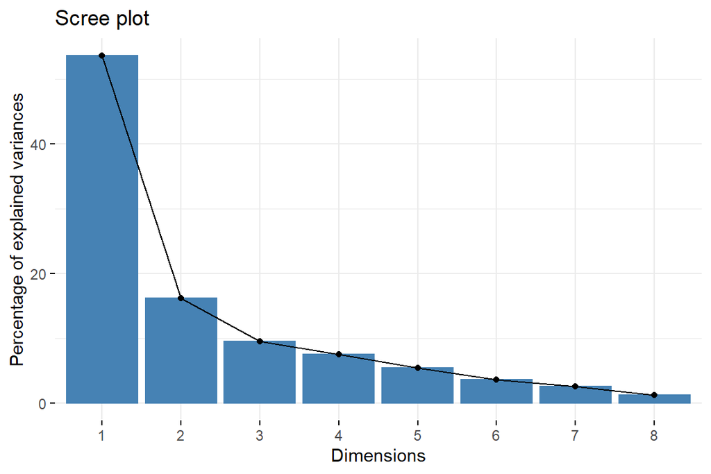

```r
fviz_eig(pca_humanstd)
```

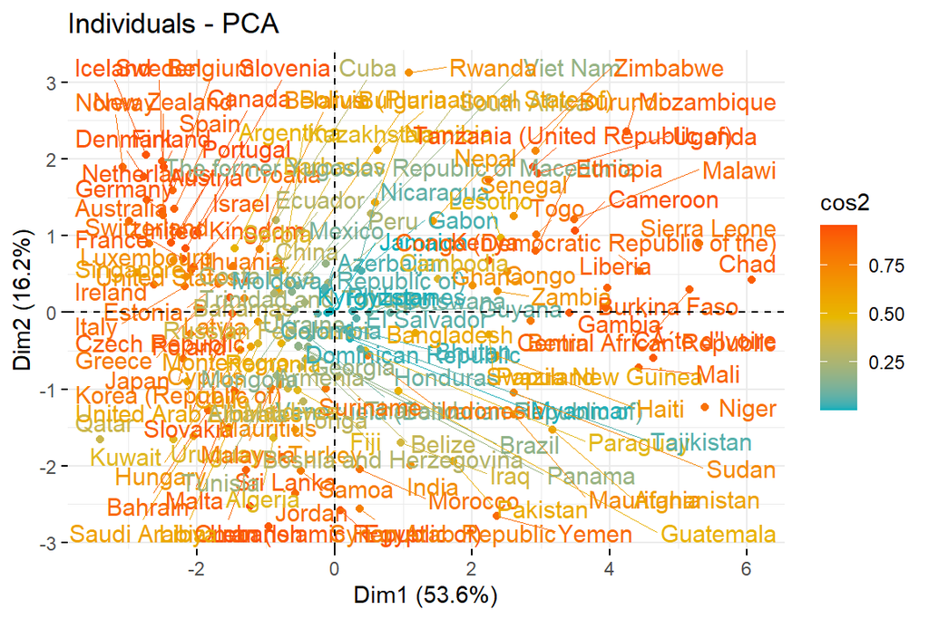

```r
fviz_pca_ind(pca_humanstd,
               col.ind = "cos2",
               gradient.cols = c("#00AFBB", "#E7B800", "#FC4E07"),
               repel = TRUE
  )
```

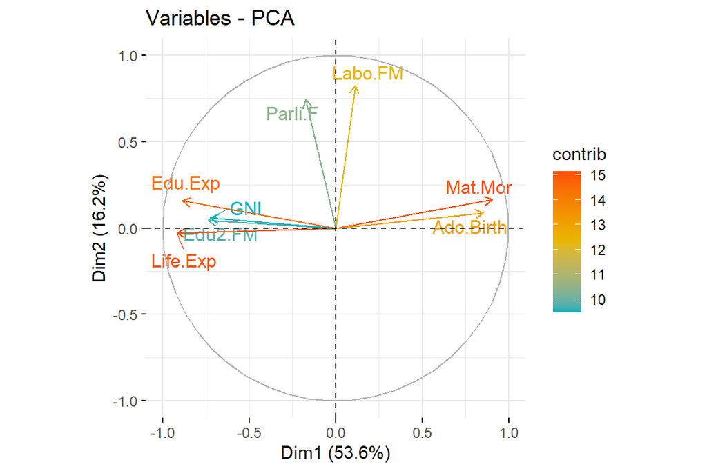

```r
fviz_pca_var(pca_humanstd,
             col.var = "contrib",
             gradient.cols = c("#00AFBB", "#E7B800", "#FC4E07"),
             repel = TRUE
             )
```

The first plot shows the percentage of variance explained by each component, being the PC1 the one explaining more variance. If we were to use these PCs for modeling purposes, we would consider to remove the last ones, as those do not account for a lot of variance.

In the second plot, observations grouped together are more similar. Fo example, we can see that many of the Nordic and European countries are grouped together in the left upper corner because they share similar features (variables). Same happens with many African countries, which are located together in the right upper corner. The colors are the quality of representation in the PCs. The last plot, shows with colours the contribution of each variable to the PC. According to the plot, *Mat.Mor*, *Life.Exp* and *Edu.Exp* contribute the most to the PCs.

**Multiple Correspondence Analysis** is another dimensionality reduction technique, which is applied when we want to analyze the dimensions using categorical variables.